# Оценка корректности проведения A/B теста и оценка результатов теста

# Содержание

- Задачи проекта
- Описание набора данных
- Календарь маркетинговых событий на 2020 год
- Таблица пользователей, зарегистрировавшихся с 7 по 21 декабря 2020 года
- Таблица действий новых пользователей в период с 7 декабря 2020 по 4 января 2021 года
- Участники тестов
- Проверка данных
- Воронка для уникальных пользователей
- Анализ результатов A/B-теста
- Выводы
- Рекомендации

# Задачи проекта

- Оценить корректность проведения теста
- Проанализировать результаты теста

Набор новых пользователей проходил с 7 по 21 декабря.

Ожидаемый результат — за 14 дней с момента регистрации пользователи покажут улучшение каждой метрики не менее, чем на 10%.

# Описание набора данных

#### `ab_project_marketing_events.csv` — календарь маркетинговых событий на 2020 год.

Структура файла:

- `name` — название маркетингового события;
- `regions` — регионы, в которых будет проводиться рекламная кампания;
- `start_dt` — дата начала кампании;
- `finish_dt` — дата завершения кампании.

#### `final_ab_new_users.csv` — пользователи, зарегистрировавшиеся с 7 по 21 декабря 2020 года.

Структура файла:

- `user_id` — идентификатор пользователя;
- `first_date` — дата регистрации;
- `region` — регион пользователя;
- `device` — устройство, с которого происходила регистрация.

#### `final_ab_events.csv` — действия новых пользователей в период с 7 декабря 2020 по 4 января 2021 года.

Структура файла:

- `user_id` — идентификатор пользователя;
- `event_dt` — дата и время покупки;
- `event_name` — тип события;
- `details` — дополнительные данные о событии. Например, для покупок, `purchase,` в этом поле хранится стоимость покупки в долларах.

#### `final_ab_participants.csv` — таблица участников тестов.

Структура файла:

- `user_id` — идентификатор пользователя;
- `ab_test` — название теста;
- `group` — группа пользователя.

```python
import pandas as pd
import numpy as np
from scipy import stats as st
import math as mth

import plotly.express as px
from plotly import graph_objects as go


import seaborn as sns
import matplotlib.pyplot as plt


import warnings
warnings.simplefilter('ignore')
```

## Календарь маркетинговых событий на 2020 год

```python
ab_project_marketing_events = pd.read_csv('')
```

```python
ab_project_marketing_events.info()
```

```
<class 'pandas.core.frame.DataFrame'>
RangeIndex: 14 entries, 0 to 13
Data columns (total 4 columns):
 #   Column     Non-Null Count  Dtype
---  ------     --------------  -----
 0   name       14 non-null     object
 1   regions    14 non-null     object
 2   start_dt   14 non-null     object
 3   finish_dt  14 non-null     object
dtypes: object(4)
memory usage: 576.0+ bytes
```

```python
ab_project_marketing_events.head(15)
```

|  | name | regions | start_dt | finish_dt |
| --- | --- | --- | --- | --- |
| 0 | Christmas&New Year Promo | EU, N.America | 2020-12-25 | 2021-01-03 |
| 1 | St. Valentine's Day Giveaway | EU, CIS, APAC, N.America | 2020-02-14 | 2020-02-16 |
| 2 | St. Patric's Day Promo | EU, N.America | 2020-03-17 | 2020-03-19 |
| 3 | Easter Promo | EU, CIS, APAC, N.America | 2020-04-12 | 2020-04-19 |
| 4 | 4th of July Promo | N.America | 2020-07-04 | 2020-07-11 |
| 5 | Black Friday Ads Campaign | EU, CIS, APAC, N.America | 2020-11-26 | 2020-12-01 |
| 6 | Chinese New Year Promo | APAC | 2020-01-25 | 2020-02-07 |
| 7 | Labor day (May 1st) Ads Campaign | EU, CIS, APAC | 2020-05-01 | 2020-05-03 |
| 8 | International Women's Day Promo | EU, CIS, APAC | 2020-03-08 | 2020-03-10 |
| 9 | Victory Day CIS (May 9th) Event | CIS | 2020-05-09 | 2020-05-11 |
| 10 | CIS New Year Gift Lottery | CIS | 2020-12-30 | 2021-01-07 |
| 11 | Dragon Boat Festival Giveaway | APAC | 2020-06-25 | 2020-07-01 |
| 12 | Single's Day Gift Promo | APAC | 2020-11-11 | 2020-11-12 |
| 13 | Chinese Moon Festival | APAC | 2020-10-01 | 2020-10-07 |

### Выводы

Маркетинговые кампании Christmas&New Year Promo и CIS New Year Gift Lottery частично пересекаются с датами теста.

Cогласно техзаданию набор новых пользователей остановлен 21 декабря, следовательно, маркетинговые мероприятия на набор новых пользователей не повлияли, но могли повлиять на решения о покупке.

Согласно источнику (https://habr.com/ru/post/233911/): 'Для снижения влияния внешних факторов, таких как рекламные кампании, день недели, погода или сезонность, замеры в сегментах важно делать параллельно, т.е. в один и тот же период времени'. В нашем случае замеры проводились паралельно.

Согласно источнику (https://habr.com/ru/company/retailrocket/blog/261593/): 'И напоследок, всегда обращайте внимание на то, когда вы запускаете тест и как долго он длится. Старайтесь не запускать тест за несколько дней до крупных гендерных праздников и в праздничные/выходные дни. Сезонность также прослеживается на уровне получения зарплат: как правило, это стимулирует продажи дорогих товаров, в частности, электроники'.

Поэтому я приняла решение отсечь в таблице действий новых пользователей действия после 25 декабря.

## Таблица пользователей, зарегистрировавшихся с 7 по 21 декабря 2020 года

```python
final_ab_new_users = pd.read_csv('')
```

```python
final_ab_new_users.info()
```

```
<class 'pandas.core.frame.DataFrame'>
RangeIndex: 61733 entries, 0 to 61732
Data columns (total 4 columns):
 #   Column      Non-Null Count  Dtype
---  ------      --------------  -----
 0   user_id     61733 non-null  object
 1   first_date  61733 non-null  object
 2   region      61733 non-null  object
 3   device      61733 non-null  object
dtypes: object(4)
memory usage: 1.9+ MB
```

```python
final_ab_new_users.head()
```

|  | user_id | first_date | region | device |
| --- | --- | --- | --- | --- |
| 0 | D72A72121175D8BE | 2020-12-07 | EU | PC |
| 1 | F1C668619DFE6E65 | 2020-12-07 | N.America | Android |
| 2 | 2E1BF1D4C37EA01F | 2020-12-07 | EU | PC |
| 3 | 50734A22C0C63768 | 2020-12-07 | EU | iPhone |
| 4 | E1BDDCE0DAFA2679 | 2020-12-07 | N.America | iPhone |

```python
final_ab_new_users.duplicated().sum()
```

```
0
```

```python
final_ab_new_users['first_date'].max()
```

```
'2020-12-23'
```

```python
final_ab_new_users = final_ab_new_users[final_ab_new_users['first_date'] <= '2020-12-21']
```

```python
pivot_table_by_region = final_ab_new_users.pivot_table(final_ab_new_users,index=["region"], aggfunc={'user_id': 'nunique'}).reset_index()
pivot_table_by_region.columns=['region','no. of users']
pivot_table_by_region
```

|  | region | no. of users |
| --- | --- | --- |
| 0 | APAC | 2883 |
| 1 | CIS | 2900 |
| 2 | EU | 42340 |
| 3 | N.America | 8347 |

### Выводы

- Данные чистые, без пропусков и дублей
- Максимальная дата в данных -- '2020-12-23', я отсекла 22 и 23 декабря, так как набор новых пользователей проходил до 21 декабря

## Таблица действий новых пользователей в период с 7 декабря 2020 по 4 января 2021 года

```python
final_ab_events = pd.read_csv('')
```

```python
final_ab_events.info()
```

```
<class 'pandas.core.frame.DataFrame'>
RangeIndex: 440317 entries, 0 to 440316
Data columns (total 4 columns):
 #   Column      Non-Null Count   Dtype
---  ------      --------------   -----
 0   user_id     440317 non-null  object
 1   event_dt    440317 non-null  object
 2   event_name  440317 non-null  object
 3   details     62740 non-null   float64
dtypes: float64(1), object(3)
memory usage: 13.4+ MB
```

```python
final_ab_events.head()
```

|  | user_id | event_dt | event_name | details |
| --- | --- | --- | --- | --- |
| 0 | E1BDDCE0DAFA2679 | 2020-12-07 20:22:03 | purchase | 99.99 |
| 1 | 7B6452F081F49504 | 2020-12-07 09:22:53 | purchase | 9.99 |
| 2 | 9CD9F34546DF254C | 2020-12-07 12:59:29 | purchase | 4.99 |
| 3 | 96F27A054B191457 | 2020-12-07 04:02:40 | purchase | 4.99 |
| 4 | 1FD7660FDF94CA1F | 2020-12-07 10:15:09 | purchase | 4.99 |

```python
final_ab_events.duplicated().sum()
```

```
0
```

```python
final_ab_events['event_dt'].min()
```

```
'2020-12-07 00:00:33'
```

```python
final_ab_events['event_dt'].max()
```

```
'2020-12-30 23:36:33'
```

```python
final_ab_events['event_dt'] = pd.to_datetime(final_ab_events['event_dt'])
```

```python
final_ab_events['event_name'].unique()
```

```
array(['purchase', 'product_cart', 'product_page', 'login'], dtype=object)
```

### Оставим только те user_id и тех пользователей, которые вошли в таблицу пользователей, зарегистрировавшихся с 7 по 21 декабря 2020 года

```python
final_ab_events = final_ab_events.query('user_id in @final_ab_new_users.user_id')
```

### Отсечем в таблице действий новых пользователей действия после 25 декабря

```python
final_ab_events = final_ab_events[final_ab_events['event_dt'] <= '2020-12-25']
```

```python
final_ab_events.info()
```

```
<class 'pandas.core.frame.DataFrame'>
Int64Index: 355148 entries, 0 to 412653
Data columns (total 4 columns):
 #   Column      Non-Null Count   Dtype
---  ------      --------------   -----
 0   user_id     355148 non-null  object
 1   event_dt    355148 non-null  datetime64[ns]
 2   event_name  355148 non-null  object
 3   details     50608 non-null   float64
dtypes: datetime64[ns](1), float64(1), object(2)
memory usage: 13.5+ MB
```

### Объединим 2 таблицы: final_ab_events и final_ab_new_users

```python
final_ab_events_region = final_ab_events.merge(final_ab_new_users, on='user_id', indicator=True)
```

```python
final_ab_events_region
```

|  | user_id | event_dt | event_name | details | first_date | region | device | _merge |
| --- | --- | --- | --- | --- | --- | --- | --- | --- |
| 0 | E1BDDCE0DAFA2679 | 2020-12-07 20:22:03 | purchase | 99.99 | 2020-12-07 | N.America | iPhone | both |
| 1 | E1BDDCE0DAFA2679 | 2020-12-09 06:21:35 | purchase | 9.99 | 2020-12-07 | N.America | iPhone | both |
| 2 | E1BDDCE0DAFA2679 | 2020-12-07 20:22:03 | login | NaN | 2020-12-07 | N.America | iPhone | both |
| 3 | E1BDDCE0DAFA2679 | 2020-12-09 06:21:35 | login | NaN | 2020-12-07 | N.America | iPhone | both |
| 4 | 7B6452F081F49504 | 2020-12-07 09:22:53 | purchase | 9.99 | 2020-12-07 | EU | iPhone | both |
| ... | ... | ... | ... | ... | ... | ... | ... | ... |
| 355143 | FE2F3BFF12E5AB13 | 2020-12-23 10:19:10 | login | NaN | 2020-12-21 | EU | Mac | both |
| 355144 | FE2F3BFF12E5AB13 | 2020-12-24 09:28:54 | login | NaN | 2020-12-21 | EU | Mac | both |
| 355145 | 7836B9BF6BC33911 | 2020-12-21 19:49:46 | login | NaN | 2020-12-21 | EU | Android | both |
| 355146 | 7836B9BF6BC33911 | 2020-12-24 06:56:08 | login | NaN | 2020-12-21 | EU | Android | both |
| 355147 | B67CEE441522031E | 2020-12-23 07:48:14 | login | NaN | 2020-12-07 | N.America | Android | both |

355148 rows × 8 columns

### Оставим в таблице действий новых пользователей только регион EU

```python
final_ab_events_region_EU = final_ab_events_region[final_ab_events_region['region']=='EU']
```

```python
final_ab_events_region_EU.info()
```

```
<class 'pandas.core.frame.DataFrame'>
Int64Index: 263547 entries, 4 to 355146
Data columns (total 8 columns):
 #   Column      Non-Null Count   Dtype
---  ------      --------------   -----
 0   user_id     263547 non-null  object
 1   event_dt    263547 non-null  datetime64[ns]
 2   event_name  263547 non-null  object
 3   details     39138 non-null   float64
 4   first_date  263547 non-null  object
 5   region      263547 non-null  object
 6   device      263547 non-null  object
 7   _merge      263547 non-null  category
dtypes: category(1), datetime64[ns](1), float64(1), object(5)
memory usage: 16.3+ MB
```

### Выводы

- Данные чистые, без пропусков и дублей
- Преобразовала столбец event_dt в формат datetime
- В таблице остались только те пользователи, которые вошли в таблицу пользователей, зарегистрировавшихся с 7 по 21 декабря 2020 года
- Я отсекла действия пользователей полсе 25 декабря, чтобы снизить влияние праздничных маркетинговых активностей.
- Тест по техническому заданию должен был идти до 4 января, но максимальная дата в данных — '2020-12-30', то есть в данные не попали действия пользователей зарегистрировавшихся в последние дни набора пользователей в тест (17-21 декабря)

## Участники тестов

```python
final_ab_participants = pd.read_csv('')
```

```python
final_ab_participants.info()
```

```
<class 'pandas.core.frame.DataFrame'>
RangeIndex: 18268 entries, 0 to 18267
Data columns (total 3 columns):
 #   Column   Non-Null Count  Dtype
---  ------   --------------  -----
 0   user_id  18268 non-null  object
 1   group    18268 non-null  object
 2   ab_test  18268 non-null  object
dtypes: object(3)
memory usage: 428.3+ KB
```

```python
final_ab_participants.sample(5)
```

|  | user_id | group | ab_test |
| --- | --- | --- | --- |
| 6468 | 7EFB5846D271DB80 | B | recommender_system_test |
| 9383 | 8BB08A422DB03D5E | B | interface_eu_test |
| 7951 | 93C90E45046887F3 | A | interface_eu_test |
| 6411 | B162D3C744807568 | B | recommender_system_test |
| 3963 | D6434FEC52FD20BE | B | recommender_system_test |

```python
final_ab_participants['ab_test'].unique()
```

```
array(['recommender_system_test', 'interface_eu_test'], dtype=object)
```

```python
len(final_ab_participants['user_id'].unique())
```

```
16666
```

```python
final_ab_participants['user_id'].duplicated().sum()
```

```
1602
```

### Выводы

- Данные чистые, без пропусков
- 1602 дубля, предполагаю, что эти пользователи участвовали в обоих тестах одновременно

### Сохраним данные только того теста, который нам нужен `recommender_system_test`, в таблицу ab_recommender_system_test

```python
ab_recommender_system_test = final_ab_participants[final_ab_participants['ab_test']=='recommender_system_test']
ab_recommender_system_test.info()
```

```
<class 'pandas.core.frame.DataFrame'>
Int64Index: 6701 entries, 0 to 6700
Data columns (total 3 columns):
 #   Column   Non-Null Count  Dtype
---  ------   --------------  -----
 0   user_id  6701 non-null   object
 1   group    6701 non-null   object
 2   ab_test  6701 non-null   object
dtypes: object(3)
memory usage: 209.4+ KB
```

```python
ab_recommender_system_test['user_id'].duplicated().sum()
```

```
0
```

### Объединим 2 таблицы: ab_recommender_system_test и final_ab_events_region_EU, в котором остались только те user_id и те пользователи, которые вошли в таблицу пользователей, зарегистрировавшихся с 7 по 21 декабря 2020 года, усеченную до 25 декабря из региона EU

```python
final_ab_events_group_eu = final_ab_events_region_EU.merge(ab_recommender_system_test, on='user_id')
```

```python
final_ab_events_group_eu.sample(5)
```

|  | user_id | event_dt | event_name | details | first_date | region | device | _merge | group | ab_test |
| --- | --- | --- | --- | --- | --- | --- | --- | --- | --- | --- |
| 15404 | F7E2CAFE32DB0B14 | 2020-12-16 21:21:54 | product_page | NaN | 2020-12-14 | EU | Android | both | A | recommender_system_test |
| 10095 | 0569D8065975599E | 2020-12-19 00:33:39 | login | NaN | 2020-12-14 | EU | Android | both | A | recommender_system_test |
| 13105 | 80313F5B33116510 | 2020-12-07 16:10:48 | login | NaN | 2020-12-07 | EU | Android | both | A | recommender_system_test |
| 7947 | 50FFF5722B886588 | 2020-12-21 09:42:19 | login | NaN | 2020-12-21 | EU | Android | both | A | recommender_system_test |
| 14417 | C1ECF0291CD025B8 | 2020-12-11 05:19:17 | login | NaN | 2020-12-11 | EU | Android | both | A | recommender_system_test |

```python
final_ab_events_group_eu.info()
```

```
<class 'pandas.core.frame.DataFrame'>
Int64Index: 20256 entries, 0 to 20255
Data columns (total 10 columns):
 #   Column      Non-Null Count  Dtype
---  ------      --------------  -----
 0   user_id     20256 non-null  object
 1   event_dt    20256 non-null  datetime64[ns]
 2   event_name  20256 non-null  object
 3   details     2739 non-null   float64
 4   first_date  20256 non-null  object
 5   region      20256 non-null  object
 6   device      20256 non-null  object
 7   _merge      20256 non-null  category
 8   group       20256 non-null  object
 9   ab_test     20256 non-null  object
dtypes: category(1), datetime64[ns](1), float64(1), object(7)
memory usage: 1.6+ MB
```

```python
final_ab_events_group_eu['event_dt'] = pd.to_datetime(final_ab_events_group_eu['event_dt'])
```

# Проверка данных

```python
pivot_table_by_group = final_ab_events_group_eu.pivot_table(index = 'group',
                                   columns = 'event_name',
                                   values = 'user_id',
                                   aggfunc = 'nunique').reset_index()
pivot_table_by_group
```

| event_name | group | login | product_cart | product_page | purchase |
| --- | --- | --- | --- | --- | --- |
| 0 | A | 2604 | 782 | 1685 | 833 |
| 1 | B | 876 | 244 | 493 | 249 |

```python
pivot_table_by_group = final_ab_events_group_eu.pivot_table(final_ab_events_group_eu,index=["group","event_name"], aggfunc={'user_id': 'nunique'}).reset_index()
pivot_table_by_group.columns=['group', 'event_name','no. of users']
fig = px.bar(pivot_table_by_group, x="group", y="no. of users", color="event_name", title="Количество уникальных пользователей по группам по типу событий")
fig.show()
```

[interactive chart not shown]

```python
events = len(final_ab_events_group_eu)
users = final_ab_events_group_eu['user_id'].nunique()

print('Всего событий в логе: {}'.format(events))
print('Всего уникальных пользователей в логе: {}'.format(users))
print('Среднее количество событий на одного пользователя: {}'.format(
                                                                     int(round(events/users, 0)),
                                                                     final_ab_events_group_eu['user_id'].value_counts().mode()[0]))
print('Временные рамки: начало {}, конец {}'.format(final_ab_events_group_eu['event_dt'].min(), final_ab_events_group_eu['event_dt'].max()))
```

```
Всего событий в логе: 20256
Всего уникальных пользователей в логе: 3481
Среднее количество событий на одного пользователя: 6
Временные рамки: начало 2020-12-07 00:05:57, конец 2020-12-24 23:58:32
```

### Выделим дату в отдельный столбец session_date

```python
final_ab_events_group_eu['session_date'] = final_ab_events_group_eu['event_dt'].dt.date
```

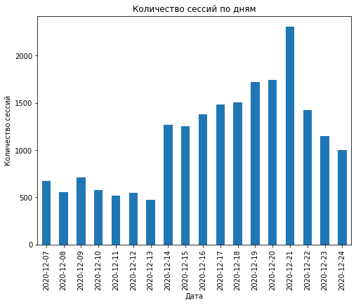

```python
final_ab_events_group_eu.groupby('session_date')['event_dt'].count().plot(kind='bar', figsize=(8,6));
plt.xlabel('Дата')
plt.ylabel('Количество сессий')
plt.title('Количество сессий по дням');
```

### Выводы

- В тестировании участвовало 3481 уникальных пользователей, в техзадании указано ожидаемое количество участников теста: 6000
- Количество пользователей в группе А: 2604
- Количество пользователей в группе B: 876
- Распределение по группам неравномерно: А = 74,9%, B = 25,1%
- Среднее количество событий на одного пользователя: 6
- Пик событий приходится на 21 декабря

# Воронка для уникальных пользователей

```python
unique_users = len(final_ab_events_group_eu['user_id'].unique())
```

```python
unique_events_count = final_ab_events_group_eu.groupby('event_name').agg({'user_id': 'nunique'}).reset_index()
unique_events_count.columns=['event_name','no. of users']
unique_events_count = unique_events_count.sort_values(by = 'no. of users', ascending=False)

unique_events_count['percent'] = ((unique_events_count['no. of users'] / unique_users)*100).round(2)

unique_events_count.head()
```

|  | event_name | no. of users | percent |
| --- | --- | --- | --- |
| 0 | login | 3480 | 99.97 |
| 2 | product_page | 2178 | 62.57 |
| 3 | purchase | 1082 | 31.08 |
| 1 | product_cart | 1026 | 29.47 |

```python
fig = go.Figure()
fig.add_trace(go.Funnel(
    y = unique_events_count['event_name'],
    x = unique_events_count['percent'],
    textinfo = "text+percent initial+value+percent previous"))
fig.update_layout(title={'text': "Воронка для уникальных пользователей"})
fig.show()
```

[interactive chart not shown]

### Выводы

Предположу, что события происходят в следующем порядке:

- login
- product_page
- product_cart
- purchase

Судя по тому, то purchase больше чем product_cart, купить товар можно минуя корзину.

- Из 3481 уникальных пользователей залогинились 3480 или 99.97%
- Основная доля посетителей — 37,4% потерялось на этапе перехода от логина к просмотру карточек товаров, на этот этап перешло 62.5%
- На этап покупок и product_cart, и purchase переходит порядка 50% посетителей предыдущего этапа (просмотр карточек товаров) и 30% от залогинившихся.

# Анализ результатов A/B-теста

```python
event_parts_per_groups = final_ab_events_group_eu.pivot_table(index='event_name', values='user_id', columns='group', aggfunc='nunique').reset_index()
```

```python
event_parts_per_groups
```

| group | event_name | A | B |
| --- | --- | --- | --- |
| 0 | login | 2604 | 876 |
| 1 | product_cart | 782 | 244 |
| 2 | product_page | 1685 | 493 |
| 3 | purchase | 833 | 249 |

```python
users_by_group_A = len(final_ab_events_group_eu[final_ab_events_group_eu['group'] == 'A']['user_id'].unique())
users_by_group_B = len(final_ab_events_group_eu[final_ab_events_group_eu['group'] == 'B']['user_id'].unique())
```

```python
event_parts_per_groups['A_part'] = event_parts_per_groups['A'] / users_by_group_A
event_parts_per_groups['B_part'] = event_parts_per_groups['B'] / users_by_group_B
event_parts_per_groups = event_parts_per_groups.set_index('event_name')
event_parts_per_groups.head()
```

| group event_name | A | B | A_part | B_part |
| --- | --- | --- | --- | --- |
| login | 2604 | 876 | 1.000000 | 0.998860 |
| product_cart | 782 | 244 | 0.300307 | 0.278221 |
| product_page | 1685 | 493 | 0.647081 | 0.562144 |
| purchase | 833 | 249 | 0.319892 | 0.283922 |

### Проверка статистической разницы долей z-критерием, при alpha = 0.01

Нулевая гипотеза: конверсии равны

```python
alpha =0.01

def Z_test(index, group_1, group_2, part_1, part_2, number_1, number_2):
    print('{}:'.format(index))
    p1 = event_parts_per_groups[part_1][index]
    p2 = event_parts_per_groups[part_2][index]
    p = (event_parts_per_groups[group_1][index]+event_parts_per_groups[group_2][index])/\
    (number_1 + number_2)
    n1 = number_1
    n2 = number_2
    z_value = (p1-p2)/mth.sqrt(p * (1-p) * (1/n1 + 1/n2))
    distr = st.norm(0, 1)
    p_value = (1 - distr.cdf(abs(z_value))) * 2
    print('p-значение: ', p_value)
    if p_value < alpha:
        print("Отвергаем нулевую гипотезу: между долями есть статистически значимая разница")
    else:
        print("Не получилось отвергнуть нулевую гипотезу, нет оснований считать доли разными")
```

```python
Z_test('product_page', 'A', 'B', 'A_part', 'B_part', users_by_group_A, users_by_group_B)

print()

Z_test('product_cart', 'A', 'B', 'A_part', 'B_part', users_by_group_A, users_by_group_B)

print()
Z_test('purchase', 'A', 'B', 'A_part', 'B_part', users_by_group_A, users_by_group_B)
```

```
product_page:
p-значение:  6.942739359416805e-06
Отвергаем нулевую гипотезу: между долями есть статистически значимая разница

product_cart:
p-значение:  0.21469192029582396
Не получилось отвергнуть нулевую гипотезу, нет оснований считать доли разными

purchase:
p-значение:  0.04652482738393027
Не получилось отвергнуть нулевую гипотезу, нет оснований считать доли разными
```

# Выводы

Проверка равенства долей выявила статистическую разницу в конверсии в просмотр карточек товаров, но результаты теста нельзя использовать для внедрения изменений, связанных с внедрением улучшенной рекомендательной системы, ввиду:

- Неккоректного деления трафика: А = 74,9%, B = 25,1%
- Пересечения теста с маркетинговыми кампаниями: Christmas&New Year Promo и CIS New Year Gift Lottery

### В тестировании участвовало 3481 уникальных пользователей, в техзадании указано ожидаемое количество участников теста: 6000

- Количество пользователей в группе А: 2604
- Количество пользователей в группе B: 876
- Распределение по группам неравномерно: А = 74,9%, B = 25,1%
- Среднее количество событий на одного пользователя: 6
- Пик событий приходится на 21 декабря

### Воронка

- Из 3481 уникальных пользователей залогинились 3480 или 99.97%
- Основная доля посетителей — 37,4% потерялось на этапе перехода от логина к просмотру карточек товаров, на этот этап перешло 62.5%
- На этап покупок и product_cart, и purchase переходит порядка 50% посетителей предыдущего этапа (просмотр карточек товаров) и 30% от залогинившихся

# Рекомендации

- Расследовать причину потери 37,4% посетителей на этапе перехода от логина к просмотру карточек товаров
- Провести повторный A/B-тест с корректным разделением пользовтелей между группами тестирования и вне праздниных дней и маркетинговых акций